# 9장

#### 활용된 데이터

- **2015년 10차 한국복지패널조사-조사설계서-가구용(beta1)**

  성별=23행 / 태어난 연도=24행 / 혼인상태=29행/ 종교=30행 / 월급=59행/지역= 10(5개권역),11(7개 권역)
- 2015년 10차 한국복지패널조사-조사설계서-가구용(beta1) :직종= 직종코드시트2

#### 만든 변수 정리: 언제 어떤 상황에서 왜 만들어졌는가.

1.sex_income: 성별에 따른 월급차이 분석해서 성별 월급 평균표를 만들 때, 전체에서 월급(income)만 필터링후, 성별로 그룹지어서 묶고 그 안에서 월급 평균을 산출하고 저장하기 위해서 만듬.

3.연령대별 월급 평균표만들기할 때 ageg_income, 그룹으로 묶어서 새로운 데이터프레임으로 만들기

4.sex_income, 연령대별로 그룹짓고 그 그룹내에서 성별로 그룹짓기 연령대별로 구분하지 않고 나이 및 성별 월급 평균표 그래프만들 때,sex_age 성별 연령별 월급 평균표 만들기

5.welfare에 직업명 결합할 때, 원데이터(welfare)와 list_job에 code_job이라는 공통된 변수가 있다.

6.직업별 월급 상위10개 내림차순으로 정렬하기 위해 top10변수/ 월급하위10개 bottom10변수

7.이혼여부 변수 만들기:welfare$group_marriage 혼인상태변수: 1번:유배우,3번:이혼만 남기고 제외하고 다 빼기

8.지역코드 목록 만들기 / 지역코드만 있으니 데이터로 만들어서 기존 데이터(welfare)에 조인하기 위해 데이터 프레임형태로 만듬. list_region변수 / 지역명 순서 변수 만들기 order 변수

===========================================================================================

#### 데이터 세팅

원본 데이터불러오기: 연습용 프로젝트라 시스템으로인해 오류남을 인지할 것!

#### 파일 경로 easy_r 로 잡아주기

```r
raw_welfare<-read.spss(file="c:\\easy_r\\Koweps_hpc10_2015_beta1.sav",to.data.frame = T)
welfare<-raw_welfare
```

#### 데이터 검토하기

head(welfare)

tail(welfare)

View(welfare)

dim(welfare)

str(welfare)

summary(welfare)

#### 변수명 쉬운 단어로 변경하기

```r
welfare <- rename(welfare,
                  sex = h10_g3, # 성별
                  birth = h10_g4, # 태어난 연도
                  marriage = h10_g10, # 혼인 상태
                  religion = h10_g11, # 종교
                  income = p1002_8aq1, # 월급
                  code_job = h10_eco9, # 직종 코드
                  code_region = h10_reg7) # 지역 코드
```

## 1-1.변수 검토하기

```r
#1.변수 검토하기
class(welfare$birth)
```

```
## [1] "numeric"
```

```r
summary(welfare$birth)
```

```
##    Min. 1st Qu.  Median    Mean 3rd Qu.    Max.
##    1907    1946    1966    1968    1988    2014
```

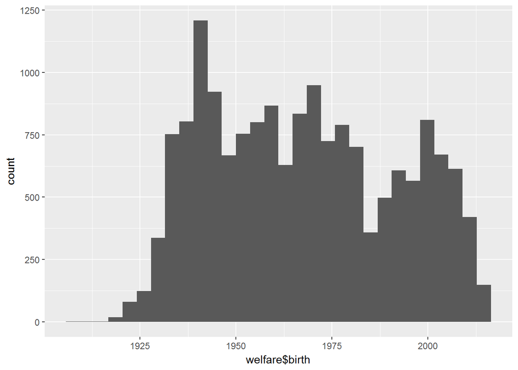

```r
qplot(welfare$birth)
```

```r
#2.전처리
#이상치 확인
summary(welfare$birth)
```

```
##    Min. 1st Qu.  Median    Mean 3rd Qu.    Max.
##    1907    1946    1966    1968    1988    2014
```

```r
table(is.na(welfare$birth))
```

```
##
## FALSE
## 16664
```

```r
#이상치 결측 처리
welfare$birth<-ifelse(welfare$birth==9999,NA,welfare$birth)
table(is.na(welfare$birth))
```

```
##
## FALSE
## 16664
```

```r
#3.파생변수 만들기-나이
welfare$age<-2018-welfare$birth+1
summary(welfare$age)
```

```
##    Min. 1st Qu.  Median    Mean 3rd Qu.    Max.
##    5.00   31.00   53.00   51.43   73.00  112.00
```

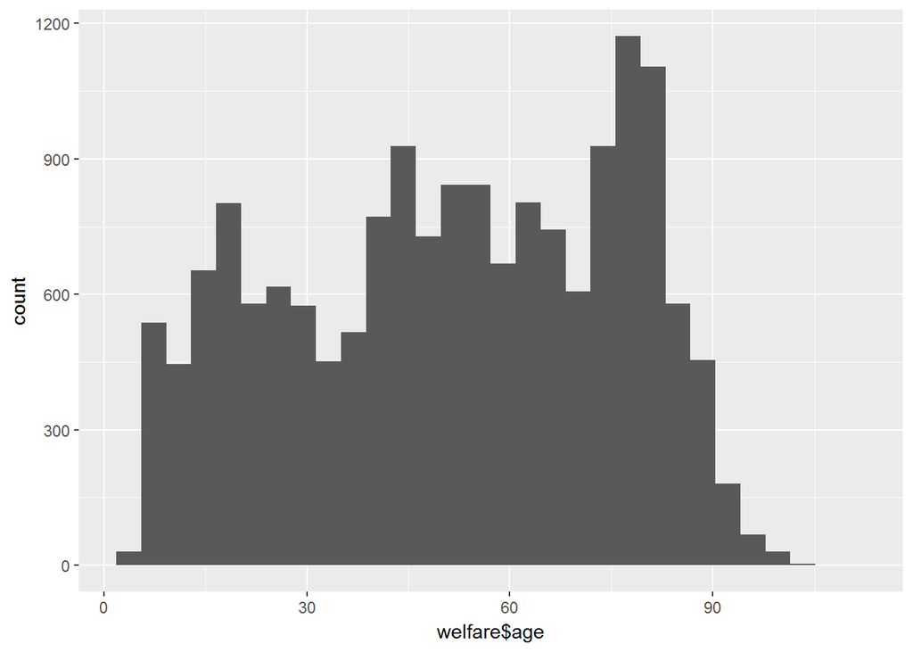

```r
qplot(welfare$age)
```

## 1-2.나이와 월급의 관계 분석하기-1.나이에 따른 월급 평균표 만들기

```r
age_income<-welfare %>%
  filter(!is.na(income)) %>%
  group_by(age) %>%
  summarise(mean_income=mean(income))
head(age_income)
```

```
## # A tibble: 6 x 2
##     age mean_income
##   <dbl>       <dbl>
## 1  23.0         121
## 2  24.0         106
## 3  25.0         130
## 4  26.0         142
## 5  27.0         134
## 6  28.0         145
```

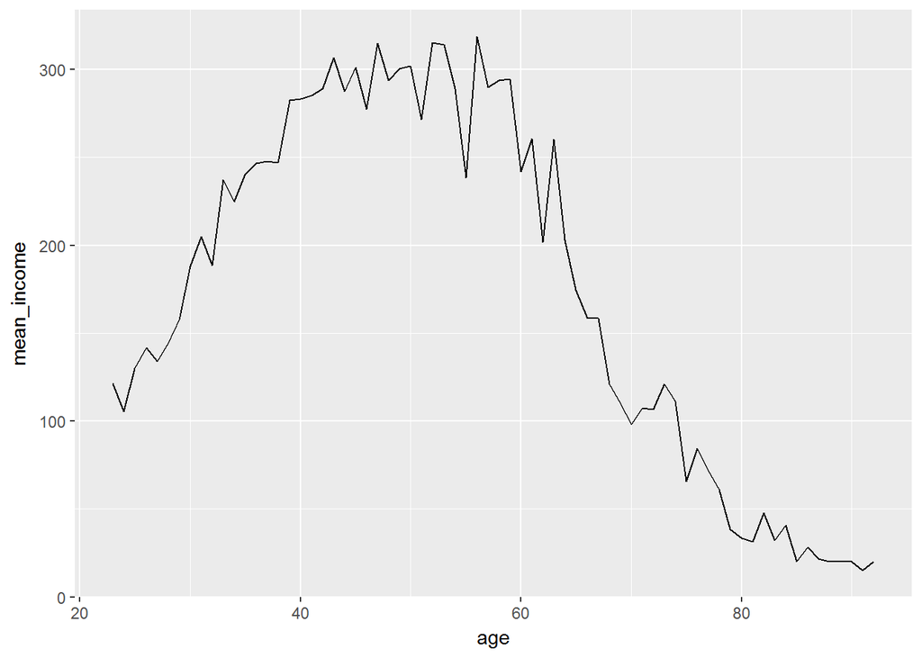

```r
#2.그래프 만들기
ggplot(data=age_income,aes(x=age,y=mean_income))+geom_line()
```